# PACTA Portfolio Alignment Report

Paris Agreement Capital Transition Assessment — Demo Portfolio Analysis

Generated: February 26, 2026 | Framework: r2dii / pacta.loanbook | Scenario: demo_2020

## 1. Executive Summary

This report presents the results of a PACTA alignment analysis applied to a demonstration loan portfolio. The analysis measures whether the real-economy activities financed by the portfolio are consistent with the Paris Agreement climate goals, using the **Market Share Approach** for power and automotive sectors, and the **Sectoral Decarbonization Approach (SDA)** for cement and steel.

177

Matched Loan–Company Pairs

4

Sectors Analyzed

0 / 4

Sectors Aligned to Scenario

2025

Target Assessment Year

## 2. Methodology

The analysis follows the standard PACTA for Banks methodology developed by RMI (Rocky Mountain Institute), implemented through the open-source `pacta.loanbook` R package ecosystem:

### Pipeline Steps

1. **Data Preparation:** A loan book (borrower names, sectors, loan amounts) is combined with the ABCD (Asset-Based Company Data) database containing physical production plans of companies in climate-relevant sectors.
2. **Matching:** Borrower names are fuzzy-matched to ABCD company names using the `r2dii.match` package. Matches are then prioritized (direct > intermediate parent > ultimate parent).
3. **Market Share Approach:** For power and automotive, the portfolio’s weighted share of technology-level production is compared against scenario-derived targets (SDS, CPS, SPS).
4. **Sectoral Decarbonization Approach (SDA):** For cement and steel, the portfolio’s weighted average CO₂ emission intensity (tCO₂/tonne of product) is compared against a scenario-derived convergence pathway.

### Scenario

This demo uses the built-in `demo_2020` scenario from the `r2dii.data` package. In a production setting, this would be replaced with IEA World Energy Outlook (SDS/STEPS/NZE) or NGFS scenarios.

### Key Metrics Explained

| Metric | Description |
| --- | --- |
| `projected` | The portfolio’s production/intensity trajectory based on matched companies’ forward-looking plans |
| `target_sds` / `target_demo` | The required trajectory under the Sustainable Development Scenario |
| `corporate_economy` | Market-wide benchmark — what the entire economy is doing |
| `adjusted_scenario_demo` | Scenario target adjusted for the portfolio’s starting point |

## 3. Data Matching & Coverage

Before any alignment analysis, the loanbook must be matched to physical asset data. The quality of this match directly impacts the reliability of results — sectors with low coverage should be interpreted cautiously.

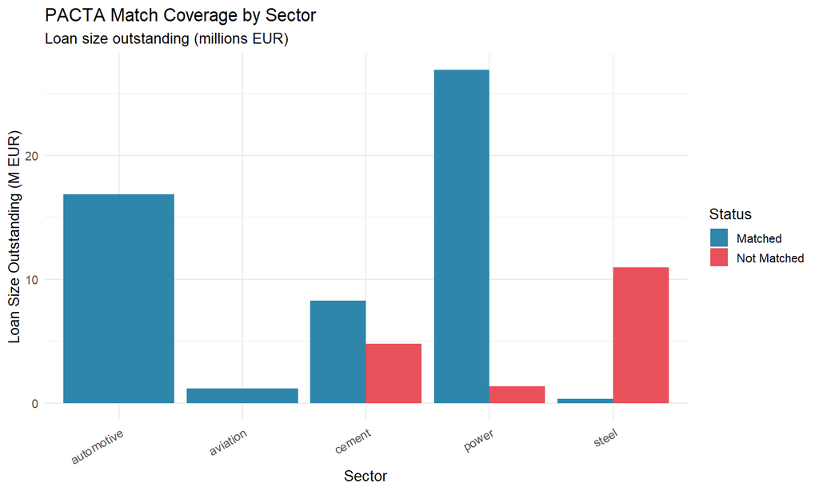

Figure 1: Loan exposure matched vs. unmatched against the ABCD database, by sector (millions EUR).

### Coverage Assessment

| Sector | Matched (M EUR) | Unmatched (M EUR) | Coverage | Quality |
| --- | --- | --- | --- | --- |
| Automotive | ~16 | ~0 | ~100% | Excellent |
| Power | ~25 | ~1 | ~96% | Very Good |
| Cement | ~8 | ~5 | ~62% | Moderate |
| Aviation | ~1 | ~0 | ~100% | Good |
| Steel | ~0.5 | ~11 | ~4% | Poor |

**Data Quality Note:** The steel sector has only ~4% match coverage. The alignment results for steel represent a tiny fraction of the portfolio’s actual steel exposure and should not be used for decision-making without further data improvement.

## 4. Power Sector Analysis

The power sector is assessed using the **Market Share Approach**, which compares the portfolio’s capacity mix across generation technologies (renewables, coal, gas, hydro, nuclear, oil) against scenario targets.

### 4.1 Technology Mix

The stacked bars below compare the portfolio’s technology share at 2020 and 2025 against the SDS target mix. A Paris-aligned portfolio should shift toward a higher renewables share and lower coal/gas share over time.

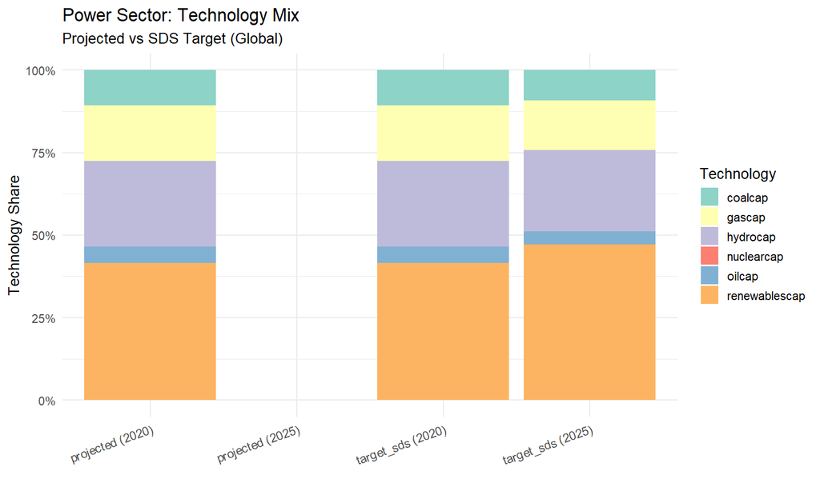

Figure 2: Power sector technology mix — projected portfolio composition vs. SDS target (2020 and 2025, global).

### 4.2 Technology Trajectories

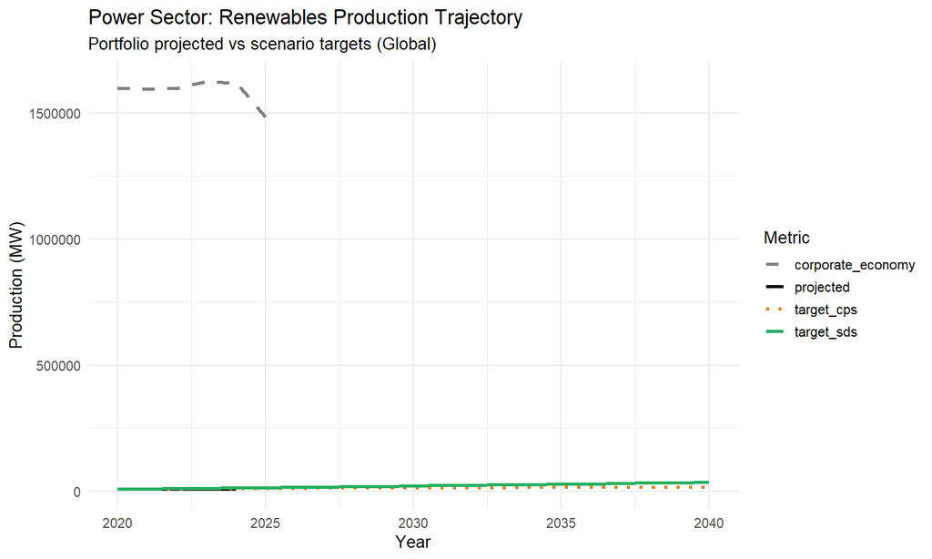

Figure 3a: Renewables capacity trajectory.

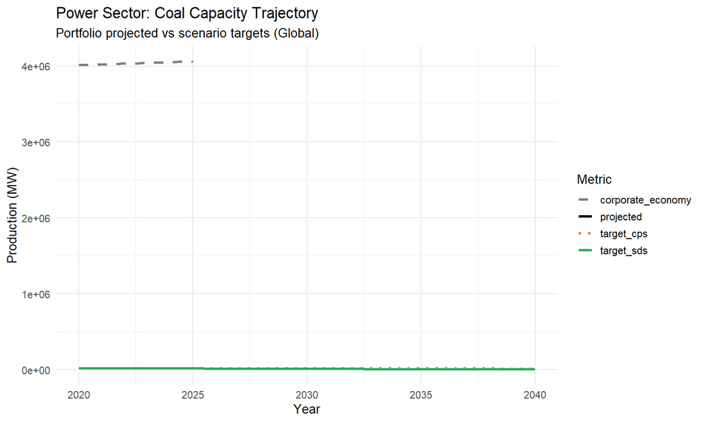

Figure 3b: Coal capacity trajectory.

The trajectory charts show the portfolio’s absolute production (black line) relative to the corporate economy benchmark (grey dashed). The portfolio holds a small fraction of global capacity, which compresses the projected and target lines near the bottom of the chart. The corporate economy benchmark (grey) dominates the y-axis scale.

**Interpretation Note:** Several power technologies (gas, hydro, nuclear, renewables) show `NA` for projected production at 2025, indicating that matched companies lack forward-looking production data for these technologies. This prevents a complete power sector alignment assessment and is flagged as a data gap.

## 5. Automotive Sector Analysis

The automotive sector is also assessed via the **Market Share Approach**, focusing on the production mix between internal combustion engine (ICE) vehicles, hybrids, and electric vehicles (EVs).

### 5.1 Technology Mix

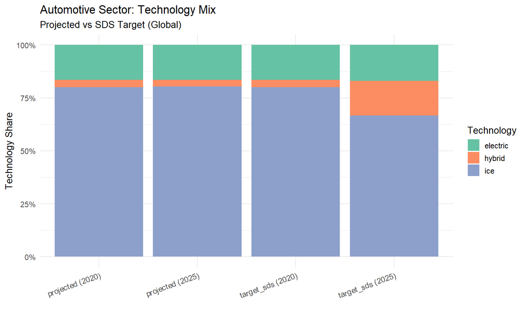

Figure 4: Automotive technology mix — projected vs. SDS target (2020 and 2025, global).

This chart reveals a clear misalignment. By 2025, the SDS scenario expects:

- **ICE share to drop** from ~81% to ~67%
- **Hybrid share to increase** from ~3% to ~16%
- **Electric share to grow** from ~16% to ~17%

However, the portfolio’s projected 2025 mix shows ICE still at ~80%, hybrids barely at ~3%, and electric at ~16%. The portfolio is essentially not transitioning.

### 5.2 Electric Vehicle Trajectory

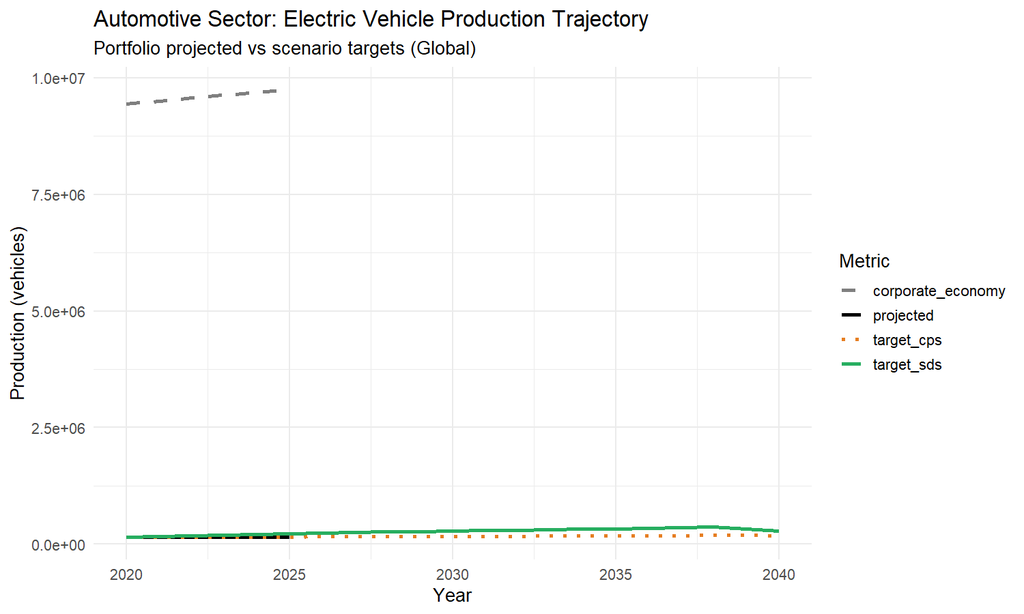

Figure 5: Electric vehicle production trajectory — portfolio projected vs. scenario targets (global).

The portfolio’s EV production (black line) tracks slightly below the SDS target (green line). While the gap is small in absolute terms, the portfolio is not keeping pace with the required ramp-up in zero-emission vehicle production.

### 5.3 Automotive Alignment at 2025

| Technology | Projected Production | SDS Target | Gap | Aligned? |
| --- | --- | --- | --- | --- |
| Electric | 154,800 | 222,159 | −67,359 | No |
| Hybrid | 114,214 | 488,138 | −373,925 | No |
| ICE | 2,276,030 | 1,980,366 | +295,663 | No* |

## 6. Cement Sector Analysis

Cement is assessed using the **Sectoral Decarbonization Approach (SDA)**, which tracks CO₂ emission intensity (tonnes of CO₂ per tonne of cement produced) against a scenario-derived convergence pathway.

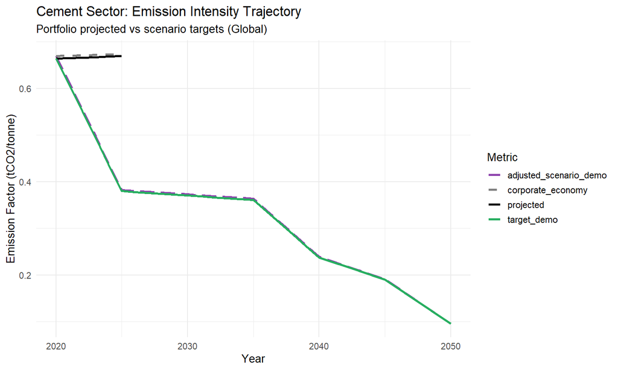

Figure 6: Cement emission intensity trajectory — portfolio projected vs. scenario targets out to 2050 (global).

### Key Observations

- The **projected** line (black) remains flat at approximately **0.67 tCO₂/tonne** through the 5-year forward-looking window (2020–2025). The portfolio’s cement companies show no planned reduction in emission intensity.
- The **target** line (green) plunges from 0.66 to **0.38 tCO₂/tonne** by 2025, and continues declining to ~0.10 by 2050.
- The **adjusted scenario** (purple) closely tracks the target, confirming the portfolio started near the market average.
- The **corporate economy** (grey dashed) also remains flat, suggesting the entire cement market is failing to decarbonize at the pace needed.

0.669

Projected Intensity (2025)

0.380

Target Intensity (2025)

+76%

Above Target

**Assessment:** The portfolio’s cement exposure is **severely misaligned**. At 0.669 tCO₂/tonne, it is 76% above the 2025 target of 0.380. This represents the widest gap of any sector in the analysis and reflects the fundamental challenge of cement decarbonization — no major breakthrough in process emissions reduction is visible in the portfolio companies’ plans.

## 7. Steel Sector Analysis

Steel is also assessed using the **SDA**, measuring tCO₂ per tonne of steel produced.

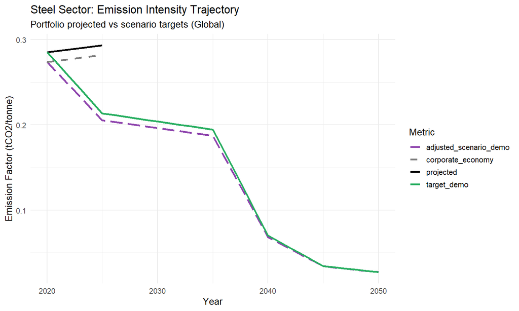

Figure 7: Steel emission intensity trajectory — portfolio projected vs. scenario targets out to 2050 (global).

### Key Observations

0.293

Projected Intensity (2025)

0.214

Target Intensity (2025)

+37%

Above Target

**Caveat:** Recall that steel match coverage is only ~4%. These results are based on a very small sample of the portfolio’s steel-related lending and may not represent the true exposure profile.

## 8. Overall Alignment Summary

The chart below shows the technology-level alignment gap for the Market Share sectors at 2025. Positive values indicate overexposure (bad for high-carbon technologies), negative values indicate underexposure (bad for low-carbon technologies).

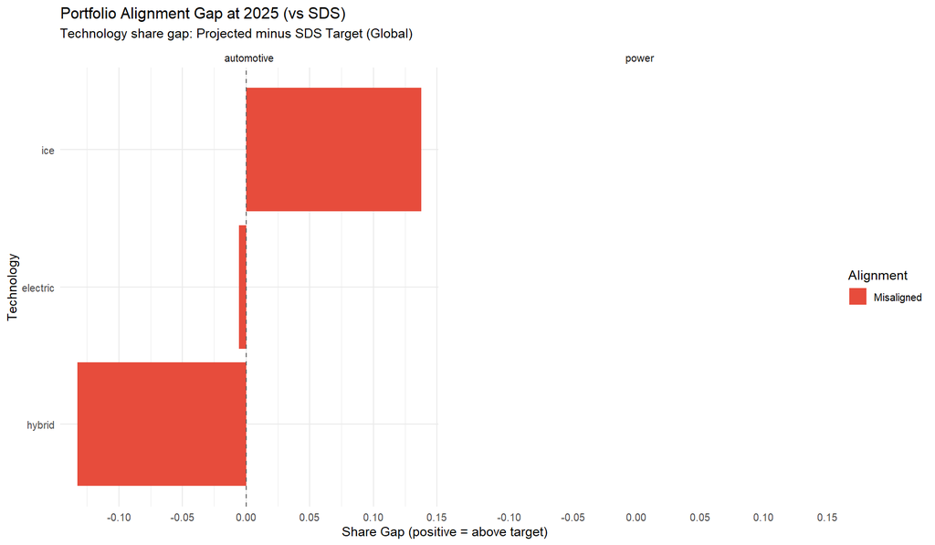

Figure 8: Portfolio alignment gap by technology at 2025 vs. SDS target. Power sector omitted due to data gaps.

The power sector panel is empty because most power technologies returned `NA` for projected values at 2025. Only automotive technologies could be assessed, and all three are misaligned.

### Consolidated Alignment Table

| Sector | Technology / Metric | Method | Gap | Status |
| --- | --- | --- | --- | --- |
| Automotive | Electric vehicles | Market Share | −0.5pp share | Misaligned |
| Automotive | Hybrid vehicles | Market Share | −13.2pp share | Misaligned |
| Automotive | ICE vehicles | Market Share | +13.8pp share | Misaligned |
| Power | All technologies | Market Share | N/A | Data Gap |
| Cement | Emission intensity | SDA | +0.289 tCO₂/t | Misaligned |
| Steel | Emission intensity | SDA | +0.080 tCO₂/t | Misaligned |

## 9. Caveats & Limitations

**This is a demonstration analysis.** The following limitations should be understood before drawing any conclusions.

1. **Demo data only:** Both the loanbook and scenario data are synthetic samples from the `pacta.loanbook` package. Results do not reflect any real institution’s portfolio.
2. **Scenario limitations:** The `demo_2020` scenario is illustrative. A real analysis would use IEA WEO, NGFS, or other authoritative scenarios with named pathways (SDS, NZE, etc.).
3. **Match coverage varies widely:** Steel at ~4% coverage cannot support meaningful conclusions. Cement at ~62% is usable but imperfect. Automotive and power have strong coverage.
4. **Power sector data gaps:** Most power technologies lack projected production data beyond the base year. A real ABCD dataset would typically provide 5–10 year forward projections.
5. **No portfolio weighting shown:** The analysis uses loan-size weighting internally, but the absolute production numbers do not directly reflect financial exposure.
6. **Point-in-time assessment:** Alignment is assessed at a single year (2025). A company that is misaligned at 2025 could still converge to the scenario path by 2030 or 2040.

## 10. Recommended Next Steps

1. **Replace demo data with real loanbook:** Prepare a CSV with columns: `id_loan`, `id_direct_loantaker`, `name_direct_loantaker`, `sector_classification_system`, `sector_classification_direct_loantaker`, `loan_size_outstanding`, `loan_size_outstanding_currency`.
2. **Source production scenarios:** Use IEA WEO or NGFS scenarios (available via the `r2dii.data` package or PACTA data downloads) for Paris-aligned pathways.
3. **Improve match coverage:** Manually review unmatched borrowers in the steel and cement sectors. Consider adding intermediate parent company names to improve fuzzy matching.
4. **Extend to additional sectors:** PACTA also supports oil & gas and aviation. Include these sectors if relevant to the portfolio.
5. **Engage with borrowers:** Use the company-level results (37,349 rows in the detailed output) to identify the specific companies driving misalignment and initiate transition dialogues.
6. **Build monitoring framework:** Re-run the analysis quarterly or semi-annually to track whether alignment is improving over time.

PACTA Portfolio Alignment Report — Generated with `pacta.loanbook` (r2dii ecosystem) — February 2026  
This report is for demonstration and educational purposes only.